# BCB420 Assignment 2 - Differential Gene expression and Preliminary ORA

Arianne Beauregard

# Install and load required packages

```r
# all required packages
bioc <- c("ComplexHeatmap", "edgeR", "limma")
cran <- c("knitr", "kableExtra", "circlize", "ggplot2", "dplyr", "gprofiler2")

# install BiocManager if needed
if (!require("BiocManager", quietly = TRUE))
    install.packages("BiocManager")

# install bioconductor packages if necessary
for (package in bioc) {
  if (!require(package, character.only = TRUE)) {
    BiocManager::install(package)
    require(package)
  }
}

# install cran packages if necessary
for(package in cran) {
  if(!require(package, character.only = TRUE)){
    install.packages(package)
    require(package)
  }
}
```

# Introduction on Data

The dataset is from a study of lipid remodeling in response to methionine stress in triple-negative breast cancer (TNBC) cells (Borrego et al., 2021). The dataset contains RNA profiles of two TNBC cell lines, one methionine-sensitive cell line (MDA-MBA-468) its methionine-insensitive derivative (MDA-MB-468res-R8), responding to methionine stress. The data was downloaded from GEO Accession GSE155955.

In Assignment 1, the data was preprocessed and normalized. Gene identifiers were mapped to their HUGO Symbols. The data was normalized using Trimmed Mean of M-values (TMM).

We will download the normalized data from Assignment 1 and take a look at the data.

```r
normalized_count_data <- readRDS("../data/normalized_count_data.rds")

kable(normalized_count_data[1:5,1:5], type="html", caption = "Table 1. A brief look at the data") %>%
  kable_styling()
```

Table 1. A brief look at the data

|  | MB468_000_01 | MB468_000_02 | MB468_000_03 | MB468_030_01 | MB468_030_02 |
| --- | --- | --- | --- | --- | --- |
| A2M | 11.409761 | 11.745209 | 11.845992 | 11.677371 | 11.554561 |
| A2ML1 | 2.876435 | 4.048334 | 3.571134 | 4.004161 | 2.984854 |
| A4GALT | 3.963662 | 5.093809 | 5.116154 | 5.319098 | 4.601493 |
| AAAS | 11.751261 | 11.752463 | 11.680160 | 11.320744 | 11.472444 |
| AACS | 13.103400 | 13.186512 | 13.188863 | 13.088211 | 12.977029 |

# Differential Gene Expression

## Determining factors

We first need to determine which factors to account for in our analysis. Let’s revisit the sample information.

There are two different cell lines (MDA-MB-468 and MDA-MB-468res-R8), measured at 4 different timepoints in hours (h) (0h, 0.5h, 2h, 12h) during methionine stress. Methionine stress was added by providing homocysteine instead of methionine in the cell lines’ growth media. There are 3 replicates for each cell line.

```r
# define groups
samples <- data.frame(lapply(colnames(normalized_count_data),
        FUN=function(x){unlist(strsplit(x,
                        split = "_"))}))
colnames(samples) <- colnames(normalized_count_data)
rownames(samples) <- c("cell.line","timepoint", "replicate")
samples <- data.frame(t(samples))
kable(samples, caption = "Table 2. Sample Groups", col.names = c("Cell Line", "Timepoint (min)", "Replicate")) %>%
  kable_styling()
```

Table 2. Sample Groups

|  | Cell Line | Timepoint (min) | Replicate |
| --- | --- | --- | --- |
| MB468_000_01 | MB468 | 000 | 01 |
| MB468_000_02 | MB468 | 000 | 02 |
| MB468_000_03 | MB468 | 000 | 03 |
| MB468_030_01 | MB468 | 030 | 01 |
| MB468_030_02 | MB468 | 030 | 02 |
| MB468_030_03 | MB468 | 030 | 03 |
| MB468_120_01 | MB468 | 120 | 01 |
| MB468_120_02 | MB468 | 120 | 02 |
| MB468_120_03 | MB468 | 120 | 03 |
| MB468_720_01 | MB468 | 720 | 01 |
| MB468_720_02 | MB468 | 720 | 02 |
| MB468_720_03 | MB468 | 720 | 03 |
| R8_000_01 | R8 | 000 | 01 |
| R8_000_02 | R8 | 000 | 02 |
| R8_000_03 | R8 | 000 | 03 |
| R8_030_01 | R8 | 030 | 01 |
| R8_030_02 | R8 | 030 | 02 |
| R8_030_03 | R8 | 030 | 03 |
| R8_120_01 | R8 | 120 | 01 |
| R8_120_02 | R8 | 120 | 02 |
| R8_120_03 | R8 | 120 | 03 |
| R8_720_01 | R8 | 720 | 01 |
| R8_720_02 | R8 | 720 | 02 |
| R8_720_03 | R8 | 720 | 03 |

We will visualize the factors of the samples in an MDS plot (Figure 1).

```r
colors <- c("blue", "red", "green4", "purple")
colors <- colors[factor(samples$timepoint)]
symbols <- c(1, 2)
symbols <- symbols[factor(samples$cell.line)]

limma::plotMDS(normalized_count_data,
               col = colors, pch = symbols, ylim = c(-1, 2.5), cex = 1.5)
title("MDS Plot of Samples")
```

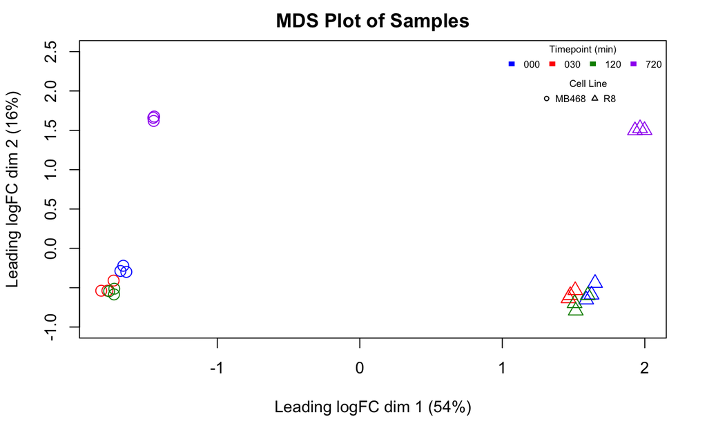

```r
legend("topright", title = "Timepoint (min)", fill = unique(colors), legend = unique(factor(samples$timepoint)), cex = 0.6, ncol = 4, bty = 'n', border = F)
legend(x = 1.25, y = 2.2, title = "Cell Line", pch=unique(symbols),legend=factor(unique(factor(samples$cell.line))), cex = 0.6, ncol = 2, bty = 'n', border = F)
```

**Figure 1. Multidimensional scaling (MDS) plot of samples.** The cluster at the bottom left is are samples of MDA-MB-468 cell line at times 0 min, 30 min and 120 min. The cluster at the bottom right is samples of MDA-MB-468res-R8 cell line at times 0 min, 30 min and 120 min. The cluster at the top left is samples of MDA-MB-468 cell line at time 720 min. The cluster at the top right is samples MDA-MB-468res-R8 cell line at time 720 min.

From the MDS plot, we can see 4 clear clusters. The clustering is based on both the cell type and timepoint, therefore our model design should account for both these factors.

## Differential expression analysis using edgeR

### Analysis for cell line MDA-MB-468

```r
counts_MB468 <- normalized_count_data[, grepl("MB468", colnames(normalized_count_data))]
samples_MB468 <- samples[colnames(counts_MB468),]


model_design <- model.matrix(~ samples_MB468$timepoint)
# DGEList
d <- DGEList(counts = counts_MB468, group = samples_MB468$timepoint)
# Estimate Dispersion with model design.
d <- estimateDisp(d, model_design)
# Fit the model
fit <- glmQLFit(d, model_design)
qlf.results <- glmQLFTest(fit, coef = "samples_MB468$timepoint720")
# take a look at results
kable(topTags(qlf.results)$table, type="html", caption = "Table 3. Results from fitting negative binomial generalized log-linear model to normalized count data of MDA-MB-468 samples") %>%
  kable_styling()
```

Table 3. Results from fitting negative binomial generalized log-linear model to normalized count data of MDA-MB-468 samples

|  | logFC | logCPM | F | PValue | FDR |
| --- | --- | --- | --- | --- | --- |
| ARHGAP25 | 3.1632889 | 5.130631 | 54.28479 | 0.0000422 | 0.5522036 |
| MIR3150BHG | -1.8195681 | 5.615789 | 159.70188 | 0.0034787 | 0.9999987 |
| TMEM156 | 1.9001420 | 5.067277 | 45.32294 | 0.0039680 | 0.9999987 |
| LINC01132 | -1.4941675 | 5.910353 | 363.71472 | 0.0046508 | 0.9999987 |
| PNPLA3 | -1.7780512 | 5.461671 | 69.87417 | 0.0065440 | 0.9999987 |
| DHRS2 | 1.0790707 | 6.059821 | 486.10562 | 0.0079353 | 0.9999987 |
| TGM5 | -1.6078621 | 5.426821 | 46.22545 | 0.0168412 | 0.9999987 |
| OASL | -1.2787888 | 5.724584 | 193.77465 | 0.0212069 | 0.9999987 |
| GPR158 | 1.4851253 | 5.140090 | 20.37917 | 0.0249433 | 0.9999987 |
| CHAC1 | 0.7823796 | 6.579820 | 2330.29016 | 0.0314440 | 0.9999987 |

We will look at the results to see how many genes pass the threshold p-value < 0.05; if the p-value is lower than 0.05, we consider the gene to be significantly differentially expressed. We also look at how many genes pass the correction. The correction method used is Benjamini-Hochberg (BH) method, which controls the false discovery rate (FDR).

```r
# all results
qlf_output_hits_MB468 <- topTags(qlf.results,sort.by = "PValue",
                           n = nrow(counts_MB468))$table

# pass the threshold p-value < 0.05
threshold_pval <- length(which(qlf_output_hits_MB468$PValue < 0.05))
print(paste("Number of genes that pass the threshold p-value < 0.05:", threshold_pval))
```

```
[1] "Number of genes that pass the threshold p-value < 0.05: 19"
```

```r
# pass correction
correction <- length(which(qlf_output_hits_MB468$FDR < 0.05))
print(paste("Number of genes that pass correction:", correction))
```

```
[1] "Number of genes that pass correction: 0"
```

Next, we will see how many genes were significantly differentially expressed. Of the genes that pass the p-value threshold of 0.05, if the log fold change is greater than 0, the gene is upregulated, and if it is less than 0, the gene is downregulated.

```r
# adding expression column to record if gene is upregulated or downregulated
qlf_output_hits_MB468 <- qlf_output_hits_MB468 %>%
  mutate(
    expression = case_when(PValue < 0.05  & logFC > 0 ~ "upregulated",
                           PValue < 0.05  & logFC < 0 ~ "downregulated",
                           TRUE ~ "unchanged")
    )

# upregulated
print(paste("Number of upregulated genes (MDA-MB-468):",
            length(which(qlf_output_hits_MB468$expression == "upregulated"))))
```

```
[1] "Number of upregulated genes (MDA-MB-468): 9"
```

```r
# downregulated
print(paste("Number of upregulated genes (MDA-MB-468):",
            length(which(qlf_output_hits_MB468$expression == "downregulated"))))
```

```
[1] "Number of upregulated genes (MDA-MB-468): 10"
```

We will visualize this in a volcano plot (Figure 2).

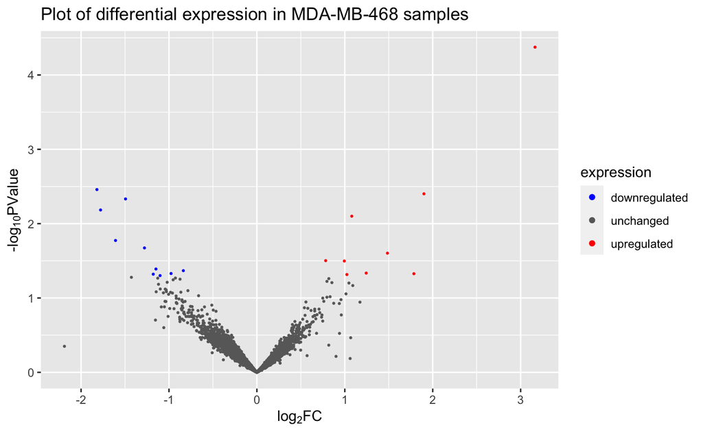

```r
# volcano plot
volcano_plot <- ggplot(qlf_output_hits_MB468, aes(logFC, -log(PValue,10))) +
  geom_point(aes(color = expression), size = 2/5) +
  xlab(expression("log"[2]*"FC")) +
  ylab(expression("-log"[10]*"PValue")) +
  ggtitle("Plot of differential expression in MDA-MB-468 samples") +
  scale_color_manual(values = c("blue", "dimgrey", "red")) +
  guides(colour = guide_legend(override.aes = list(size=1.5)))
volcano_plot
```

**Figure 2. Volcano Plot of differential expression in MDA-MB-468 samples.** The points on the plot represent genes. Red points are upregulated, blue points are downregulated, and grey points are unchanged.

### Analysis for cell line MDA-MB-468res-R8

The same process is carried out for samples of cell line MDA-MB-468res-R8.

```r
counts_R8 <- normalized_count_data[, grepl("R8", colnames(normalized_count_data))]
samples_R8 <- samples[colnames(counts_R8),]


model_design <- model.matrix(~ samples_R8$timepoint)
# DGEList
d <- DGEList(counts = counts_R8, group = samples_R8$timepoint)
# Estimate Dispersion with model design.
d <- estimateDisp(d, model_design)
# Fit the model
fit <- glmQLFit(d, model_design)
qlf.results <- glmQLFTest(fit, coef = "samples_R8$timepoint720")
# take a look at results
kable(topTags(qlf.results)$table, type="html", caption = "Table 4. Results from fitting negative binomial generalized log-linear model to normalized count data of MDA-MB-468res-R8 samples") %>%
  kable_styling()
```

Table 4. Results from fitting negative binomial generalized log-linear model to normalized count data of MDA-MB-468res-R8 samples

|  | logFC | logCPM | F | PValue | FDR |
| --- | --- | --- | --- | --- | --- |
| TMEM238L | -3.0357678 | 5.458397 | 63.59605 | 0.0002352 | 0.9999995 |
| PNPLA3 | -3.2107842 | 5.335627 | 65.87941 | 0.0002543 | 0.9999995 |
| NR4A3 | -1.3798943 | 6.511295 | 666.95121 | 0.0007123 | 0.9999995 |
| TCIM | -2.5084121 | 5.608795 | 81.25583 | 0.0009883 | 0.9999995 |
| EGR4 | -2.1866508 | 5.773591 | 150.59473 | 0.0010075 | 0.9999995 |
| SH2D1A | -2.1200304 | 5.682499 | 173.69510 | 0.0016231 | 0.9999995 |
| TNFRSF8 | -2.3335309 | 5.299903 | 49.80200 | 0.0019975 | 0.9999995 |
| BSND | -1.9779001 | 5.656512 | 38.86795 | 0.0029359 | 0.9999995 |
| EGR3 | -1.5051576 | 6.213254 | 407.70488 | 0.0033678 | 0.9999995 |
| NR4A1 | -0.9983858 | 6.811637 | 1584.08840 | 0.0060345 | 0.9999995 |

We will look at the results to see how many genes pass the threshold p-value < 0.05, and how many genes pass the correction. The same methods for the previous analysis are applied here.

```r
# all results
qlf_output_hits_R8 <- topTags(qlf.results,sort.by = "PValue",
                           n = nrow(counts_R8))$table
# pass the threshold p-value < 0.05
threshold_pval <- length(which(qlf_output_hits_R8$PValue < 0.05))
print(paste("Number of genes that pass the threshold p-value < 0.05:", threshold_pval))
```

```
[1] "Number of genes that pass the threshold p-value < 0.05: 33"
```

```r
# pass correction
correction <- length(which(qlf_output_hits_R8$FDR < 0.05))
print(paste("Number of genes that pass correction:", correction))
```

```
[1] "Number of genes that pass correction: 0"
```

Next, we will see how many genes were significantly differentially expressed.

```r
# adding expression column to record if gene is upregulated, downregulated or unchanged
qlf_output_hits_R8 <- qlf_output_hits_R8 %>%
  mutate(
    expression = case_when(PValue < 0.05  & logFC > 0 ~ "upregulated",
                           PValue < 0.05  & logFC < 0 ~ "downregulated",
                           TRUE ~ "unchanged")
    )

# upregulated
print(paste("Number of upregulated genes (MDA-MB-468res-R8):",
            length(which(qlf_output_hits_R8$expression == "upregulated"))))
```

```
[1] "Number of upregulated genes (MDA-MB-468res-R8): 2"
```

```r
# downregulated
print(paste("Number of upregulated genes (MDA-MB-468res-R8):",
            length(which(qlf_output_hits_R8$expression == "downregulated"))))
```

```
[1] "Number of upregulated genes (MDA-MB-468res-R8): 31"
```

[figure not shown]

```r
# volcano plot
volcano_plot <- ggplot(qlf_output_hits_MB468, aes(logFC, -log(PValue,10))) +
  geom_point(aes(color = expression), size = 2/5) +
  xlab(expression("log"[2]*"FC")) +
  ylab(expression("-log"[10]*"PValue")) +
  ggtitle("Plot of differential expression in MDA-MB-468res-R8 samples") +
  scale_color_manual(values = c("blue", "dimgrey", "red")) +
  guides(colour = guide_legend(override.aes = list(size=1.5)))
volcano_plot
```

## Heatmap of top hits

We will visualize all our top hits with a heatmap (Figure 4). We will create the heatmap using the data from the differentially expressed genes.

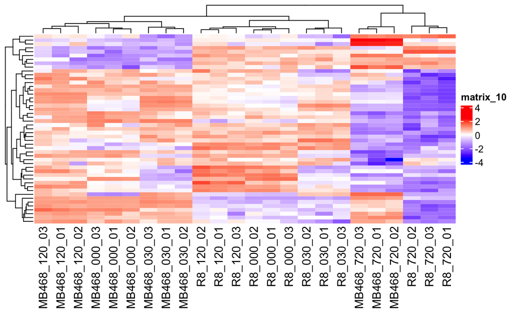

```r
# getting all differentially expressed genes (not unchaged)
mb468_deg <- row.names(qlf_output_hits_MB468)[qlf_output_hits_MB468$expression != "unchanged"]
r8_deg <- row.names(qlf_output_hits_R8)[qlf_output_hits_R8$expression != "unchanged"]

rows <- union(mb468_deg, r8_deg)

top_hits <- normalized_count_data[rows, ]

heatmap_matrix <- t(scale(t(top_hits)))
if(min(heatmap_matrix) == 0){
    heatmap_col = colorRamp2(c( 0, max(heatmap_matrix)),
                      c( "white", "red"))
  } else {
    heatmap_col = colorRamp2(c(min(heatmap_matrix), 0,
        max(heatmap_matrix)), c("blue", "white", "red"))
  }
tophits_heatmap <- Heatmap(as.matrix(heatmap_matrix),
      show_row_dend = TRUE,show_column_dend = TRUE,
      col=heatmap_col,show_column_names = TRUE,
      show_row_names = FALSE, show_heatmap_legend = TRUE)

tophits_heatmap
```

**Figure 4. Heatmap of differentially expressed genes.** The heatmap includes differentially expressed genes. The same clustering seen in the MDS plot (Figure 1) is seen in the heatmap.

# Thresholded over-representation analysis

For the thresholds, for upregulated, the p- value is less than 0.05 and the log fold change is greater than 0. For downregulated, the p- value is less than 0.05 and the log fold change is less than 0. These were determined in the previous section.

We will first see how many upregulated genes, downregulated genes, and differentially expressed genes there are.

```r
upregulated_MB468 <- row.names(qlf_output_hits_MB468)[(which(qlf_output_hits_MB468$expression ==
                                                           "upregulated"))]
upregulated_R8 <- row.names(qlf_output_hits_R8)[(which(qlf_output_hits_R8$expression ==
                                                           "upregulated"))]
upregulated <- union(upregulated_MB468, upregulated_R8)
downregulated_MB468 <- row.names(qlf_output_hits_MB468)[(which(qlf_output_hits_MB468$expression ==
                                                           "downregulated"))]
downregulated_R8 <- row.names(qlf_output_hits_R8)[(which(qlf_output_hits_R8$expression ==
                                                           "downregulated"))]
downregulated <- union(downregulated_MB468, downregulated_R8)
all_degs <- union(upregulated, downregulated)

# number of upregulated genes
length(upregulated)
```

```
[1] 11
```

```r
# number of downregulated genes
length(downregulated)
```

```
[1] 38
```

```r
# number of differentially expressed genes
length(all_degs)
```

```
[1] 49
```

## Upregulated genes

With the upregulated genes, no terms were found to be significantly enriched.

```r
upreg_res <- gost(upregulated, organism = "hsapiens", sources = "GO:BP")

if(is.null(upreg_res)) {
  print("No significantly enriched terms")
}
```

```
[1] "No significantly enriched terms"
```

## Downregulated genes

With the downregulated genes, two terms were found to be significantly enriched.

```r
downreg_res <- gost(downregulated, organism = "hsapiens", sources = "GO:BP")

downreg_df <- data.frame(term_id = downreg_res$result$term_id,
                      term_name = downreg_res$result$term_name,
                      pval = downreg_res$result$p_value)

kable(downreg_df, caption = "Table 5. Significantly Enriched Terms (Downregulated Genes)", col.names = c("Term ID", "Term Names", "P-value")) %>%
  kable_styling()
```

Table 5. Significantly Enriched Terms (Downregulated Genes)

| Term ID | Term Names | P-value |
| --- | --- | --- |
| GO:0043435 | response to corticotropin-releasing hormone | 0.0220369 |
| GO:0071376 | cellular response to corticotropin-releasing hormone stimulus | 0.0220369 |

## All differentially expressed genes

```r
all_degs_res <- gost(all_degs, organism = "hsapiens", sources = "GO:BP")

all_degs_df <- data.frame(term_id = all_degs_res$result$term_id,
                      term_name = all_degs_res$result$term_name,
                      pval = all_degs_res$result$p_value)

kable(all_degs_df, caption = "Table 6. Significantly Enriched Terms (All Differentially Expressed Genes)", col.names = c("Term ID", "Term Names", "P-value")) %>%
  kable_styling()
```

Table 6. Significantly Enriched Terms (All Differentially Expressed Genes)

| Term ID | Term Names | P-value |
| --- | --- | --- |
| GO:0051716 | cellular response to stimulus | 0.0008220 |
| GO:0050896 | response to stimulus | 0.0014324 |
| GO:0008219 | cell death | 0.0149507 |
| GO:0006915 | apoptotic process | 0.0285364 |
| GO:0012501 | programmed cell death | 0.0379435 |
| GO:0070887 | cellular response to chemical stimulus | 0.0413698 |
| GO:0010941 | regulation of cell death | 0.0425688 |
| GO:0043435 | response to corticotropin-releasing hormone | 0.0436816 |
| GO:0071376 | cellular response to corticotropin-releasing hormone stimulus | 0.0436816 |

# Interpretation

Three terms that were significantly enriched terms were related to response to stimulus. Given that the samples’ environment changed when methionine stress was added, these pathways were likely enriched because the cell lines were responding to the change in environment.

Four of the terms that were significantly enriched terms were related to cell death. Cancer cells have a metabolic requirement for methionine (Borrego et al. 2021). Therefore, when methionine was replaced with homocysteine, the TNBC cells were deprived of an essential metabolic requirement, possibly leading to cell death. Therefore, these pathways relating to cell death were significantly enriched.

Two significantly enriched terms were response to corticotropin-releasing hormone. There are a few studies that observe some link between corticotropin-releasing hormone and methionine. One study showed that peptide histidine methionine strongly potentiated corticotropin-releasing hormone induced adrenocorticotropic hormone (ACTH) secretion in humans (Sasaki et al. 1987). However, the exact link between these pathways and the experimental data is unclear.

# References

Borrego et al. (2021) Robinson, McCarthy, and Smyth (2010) Ritchie et al. (2015) Gu (2022) Gu et al. (2014) Xie (2023) Zhu (2021) Wickham (2016) Wickham et al. (2023) Kolberg et al. (2020) Sasaki et al. (1987)

Borrego, Stacey L., Johannes Fahrmann, Jue Hou, Da-Wei Lin, Bruce J. Tromberg, Oliver Fiehn, and Peter Kaiser. 2021. “Lipid Remodeling in Response to Methionine Stress in MDA-MBA-468 Triple-Negative Breast Cancer Cells.” *Journal of Lipid Research* 62: 100056. https://doi.org/https://doi.org/10.1016/j.jlr.2021.100056.

Gu, Zuguang. 2022. “Complex Heatmap Visualization.” *iMeta*. https://doi.org/10.1002/imt2.43.

Gu, Zuguang, Lei Gu, Roland Eils, Matthias Schlesner, and Benedikt Brors. 2014. “Circlize Implements and Enhances Circular Visualization in r.” *Bioinformatics* 30: 2811–12.

Kolberg, Liis, Uku Raudvere, Ivan Kuzmin, Jaak Vilo, and Hedi Peterson. 2020. “Gprofiler2– an r Package for Gene List Functional Enrichment Analysis and Namespace Conversion Toolset g:profiler.” *F1000Research* 9 (ELIXIR) (709).

Ritchie, Matthew E, Belinda Phipson, Di Wu, Yifang Hu, Charity W Law, Wei Shi, and Gordon K Smyth. 2015. “limma Powers Differential Expression Analyses for RNA-Sequencing and Microarray Studies.” *Nucleic Acids Research* 43 (7): e47. https://doi.org/10.1093/nar/gkv007.

Robinson, Mark D, Davis J McCarthy, and Gordon K Smyth. 2010. “edgeR: A Bioconductor Package for Differential Expression Analysis of Digital Gene Expression Data.” *Bioinformatics* 26 (1): 139–40. https://doi.org/10.1093/bioinformatics/btp616.

Sasaki, Atsushi, Shuichi Sato, Meigan Go, Osamu Murakami, Kunihiko Hanew, and Kaoru Yoshinaga. 1987. “Potentiation of peptide histidine methionine (PHM) on corticotropin-releasing hormone (CRH) induced ACTH secretion in humans.” *The Journal of Clinical Endocrinology & Metabolism* 65 (6): 1305–7. https://doi.org/10.1210/jcem-65-6-1305.

Wickham, Hadley. 2016. *Ggplot2: Elegant Graphics for Data Analysis*. Springer-Verlag New York. https://ggplot2.tidyverse.org.

Wickham, Hadley, Romain François, Lionel Henry, Kirill Müller, and Davis Vaughan. 2023. *Dplyr: A Grammar of Data Manipulation*. https://CRAN.R-project.org/package=dplyr.

Xie, Yihui. 2023. *Knitr: A General-Purpose Package for Dynamic Report Generation in r*. https://yihui.org/knitr/.

Zhu, Hao. 2021. *kableExtra: Construct Complex Table with ’Kable’ and Pipe Syntax*. https://CRAN.R-project.org/package=kableExtra.